# Markdown

# marimo in Markdown!

Everything in marimo is pure Python, but sometimes, annotating your notebook in markdown can be a little cumbersome. For example, here’s the code that rendered the above title and paragraph:

````markdown
```{.python.marimo}
mo.md(
    '''
    # marimo in Markdown!

    Everything in marimo is pure Python, but sometimes, annotating your notebook
    in markdown can be a little cumbersome.
    '''
)
```
````

with markdown notebook support for marimo, you can write and save markdown directly, and marimo will execute the necessary Python code for you behind the scenes. This allows you to focus on prose, and not formatting your text in a block string. ## Python cells in markdown

When you do need to create a Python cell in the markdown format, you can use a special code block:

````markdown
```{.python.marimo}
import matplotlib.pyplot as plt
plt.plot([1, 2, 3, 4])
```
````

This will create the following cell:

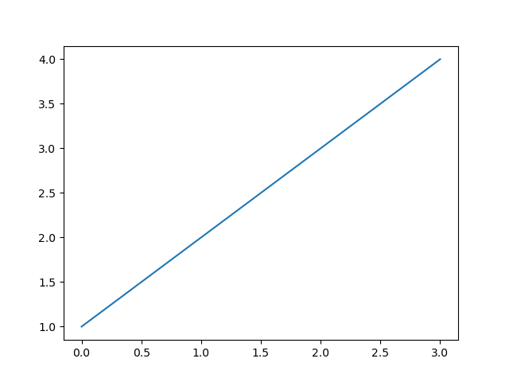

As long as your code block contains the word `python` in a brace, like `{.python.marimo}`, or `{.python note="Whatever you want"}`, marimo will treat it as a Python cell. ## Exporting from Python

Do you have a notebook that you think might better be suited for a markdown notebook? You can export your notebook to markdown by running the following code:

```bash
$ marimo export md my_marimo.py > my_marimo.md
```

````markdown
```{.python.marimo hide_code="true"}
import pandas as pd
pd.DataFrame({'a': [1, 2, 3], 'b': [4, 5, 6]})
```
````

|  | a | b |
| --- | --- | --- |
| 0 | 1 | 4 |
| 1 | 2 | 5 |
| 2 | 3 | 6 |

````markdown
```{.python.marimo disabled="true"}
print("This code cell is disabled, there should be no output!")
```
````

Additionally, marimo knows when your code has a syntax issue:

````markdown
```{.python.marimo}
print("This code cell has a syntax error"
```
````

and on notebook save, will annotate the cell for you:

````markdown
```{.python.marimo unparseable="true"}
print("This code cell has a syntax error"
```
````

## Limitations of the markdown format

marimo’s markdown support treats markdown as just plain old markdown. This means that trying to use string interpolation (like this `f"{'🍃' * 7}"`) will just give you the raw string. This is a benefit, as you can clearly delineate what values are supposed to be computed, and what values are static;

and there’s nothing stopping you from executing python to achieve the same effect,

```
🍃🍃🍃🍃🍃🍃🍃
```

### Limitations on conversion

Whenever you try to implement a cell block like this:

````markdown
```{.python.marimo}
mo.md("This is a markdown cell")
```
````

The markdown format will know to automatically keep this as markdown. However, some ambiguous cases can’t be converted to markdown like this:

This is a markdown cell with an execution block in it

```
# To ambiguous to convert
```

It’s not likely that you’ll run into this issue, but rest assured that marimo is working behind the scenes to keep your notebooks unambiguous and clean as possible. ### More limitations

Since the markdown notebook really is just markdown, you can’t import from a markdown notebook cells like you can in a python notebook; but you can still give your cells a name:

````markdown
```{.python.marimo name="maybe"}
# 🎵 Hey, I just met you, and this is crazy
```
````

you can even run a notebook:

```bash
$ marimo run my_marimo.md
```

the markdown format is supposed to lower the barrier for writing text heavy documents, it’s not meant to be a full replacement for the python notebook format. You can always convert back to a python notebook if you need to:

```bash
$ marimo convert my_marimo.md > my_marimo.py
```

## More?!

Be sure to checkout the markdown.py tutorial for more information on to type-set and render markdown in marimo.

Back to top